# Predict the Price of a Diamond: Using Shiny

Aloysius Cornelio  
September 22nd, 2017

### Overview

This presentation uses Shiny to build an interactive web application that predicts the price of a diamond from its carat weight.

The user picks a carat weight by moving a slider, and the application predicts the price for the diamond using a linear regression model. The predicted price is printed on the web page in real time, and the carat-price point is displayed on a scatter plot as a green diamond as well. The scatter plot of the data used by the prediction model is also displayed.

This web application was built in R Studio using Shiny. It has 2 files, ui.R and server.R, for the user interface and the server respectively.

The user interface file, ui.R, presents the user with a slider to input the carat weight and then displays the predicted price. The server file, server.R, predicts the price using a linear regression model that it builds from the data. The server uses a random subset (of 500 observations) of the diamonds data in R.

### Data Processing

```r
library(ggplot2)
data(diamonds)
myData <- diamonds[sample(1:nrow(diamonds), 500, replace=FALSE),]
myData <- myData[, c("carat", "price")]
```

500 samples are randomly selected without replacement from the diamonds dataset.

Only the carat and the price variables are retained, the rest are discarded.

The distribution of the 500 samples is shown on the left. It will change each time the application is run.

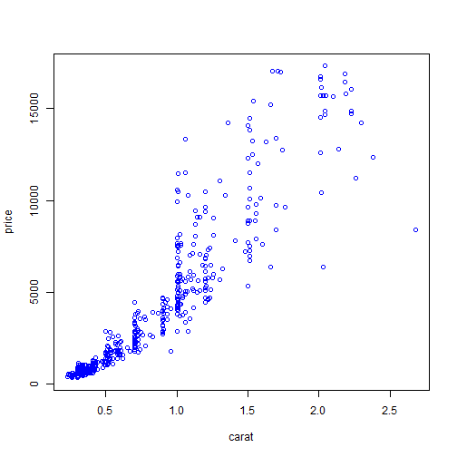

```r
plot(myData, col="blue")
```

### The Shiny User Interface: ui.R

```r
library(shiny)
shinyUI(fluidPage(
  titlePanel( title = h2("Predict the Price of a Diamond by Carat", align = "center")),
  sidebarLayout(
    sidebarPanel(
      sliderInput(inputId = "carat", label = strong("Carat:"),
                   min = 0.02, max = 5.01, value = 2.0, step = 0.01),
      HTML("Higher carat costs more.")
    ),
    mainPanel(
      helpText( "Select the Carat by the slider. ..." ),
      plotOutput("plot"),
      h4("The predicted price of a Diamond in US dollars is: "),
      textOutput("pred")
    )
  )
))
```

The sidebarPanel gets the carat weight by using a slider. The mainPanel displays the price on a scatter plot and prints it out.

### The Shiny Server: server.R

```r
library(shiny)
library(ggplot2)
data(diamonds)
shinyServer(function(input, output) {
  myData <- diamonds[sample(1:nrow(diamonds), 500, replace=FALSE),]
  myData <- myData[, c("carat", "price")]

  model <- lm(price ~ carat, data = myData)

  modelpred <- reactive({ caratinput <- input$carat
    predict(model, newdata = data.frame(carat = caratinput)) })

  output$plot <- renderPlot({
    caratinput <- input$carat
    plot(myData$price, myData$carat, xlab = "Price", ylab = "Carat", pch=16, col="blue")
    points(modelpred(), caratinput, col="red", pch=23, bg="green", cex=2)
  })

  output$pred <- renderText({ modelpred() })
})
```

The data is first prepared, and a linear regression model is created from this data. The price is predicted from the carat weight, and the outputs (a scatter plot, and the price) are generated.